# General pattern of phenotypic variation

Keisuke Atsumi

20/06/16 11:20

# Setup

## Custom functions

```r
> #' Title: the function to get prediction intervals (crediblity intervals) from rma objects (metafor)
> #'
> #' @param model: rma.mv object
> #' @param mod: the name of a moderator
> get_pred <- function(model, mod = " ") {
+   I2 <- i2_ml(model) %>%
+     as.data.frame() %>%
+     rownames_to_column("Partition") %>%
+     rename("I2" = ".") %>%
+     mutate(percentage = str_c(round(I2*100,1),"%", sep = "")) %>%
+     column_to_rownames("Partition")
+
+   name <- as.factor(str_replace(row.names(model$beta), mod, ""))
+   len <- length(name)
+
+   if (len != 1) {
+       newdata <- matrix(NA, ncol = len, nrow = len)
+       for (i in 1:len) {
+           # getting the position of unique case from X (design matrix)
+           pos <- which(model$X[, i] == 1)[[1]]
+           newdata[, i] <- model$X[pos, ]
+       }
+       pred <- predict.rma(model, newmods = newdata)
+     } else {
+         pred <- predict.rma(model)
+     }
+
+     table <- tibble(
+       'Dataset' = "",
+       'Fixed effects' = name,
+       'Estimate' = model$beta, # regression: estimate
+       'LowerCI' = model$ci.lb, # regression: 95ci,
+       'UpperCI'  = model$ci.ub, # regression: 95ci
+       'lowerPR' = pred$cr.lb,  # lower prediction range
+       'upperPR' = pred$cr.ub, # lower prediction range
+       'P'        = model$pval,
+     # 'V[species with phylogeny]' =
+     #   c(model$sigma2[1], rep("", length(model$beta))),
+     # 'V[study]' =
+     #   c(model$sigma2[2], rep("", length(model$beta))),
+     # 'V[crossed strain]' =
+     #   c(model$sigma2[3], rep("", length(model$beta))),
+     # 'V[residual]' =
+     #   c(model$sigma2[4], rep("", length(model$beta))),
+     'I2[total]' =
+       c(I2["I2_total","percentage"], rep("", length(model$beta)-1)),
+     '%I2[species with phylogeny]' =
+       c(I2["I2_spL.name","percentage"], rep("", length(model$beta)-1)),
+     '%I2[study]' =
+       c(I2["I2_Study.ID","percentage"], rep("", length(model$beta)-1)),
+     '%I2[crossed strain]' =
+       c(I2["I2_Cross.ID","percentage"], rep("", length(model$beta)-1)),
+     '%I2[residual]' =
+       c(I2["I2_ES.ID","percentage"], rep("", length(model$beta)-1)),
+     )  %>%
+     as.data.frame() %>%
+     mutate_at(vars('Estimate':'P'), as.numeric) %>%
+     mutate(significance = ifelse(P < 0.05, "*", ""))
+ }
>
> #' Title: the function to get summary stats from rma objects (metafor)
> #'
> #' @param model: rma.mv object
> #' @param mod: the name of a moderator
> get_stats <- function(model, mod = " ") {
+
+     table <- tibble(
+       'Fixed_effects' = row.names(model$beta),
+       'Estimate' = model$beta, # regression: estimate
+       'LowerCI' = model$ci.lb, # regression: 95ci,
+       'UpperCI'  = model$ci.ub, # regression: 95ci
+       'P'        = model$pval
+       )  %>%
+       as.data.frame() %>%
+       mutate(significance = ifelse(P < 0.05, "*", ""))
+ }
>
>
> #' Title: the function to get summary stats from rma objects (metafor)
> #'
> #' @param model: rma.mv object
> #' @param mod: the name of a moderator
> get_reg <- function(model, mod = " ") {
+
+   I2 <- i2_ml(model) %>%
+     as.data.frame() %>%
+     rownames_to_column("Partition") %>%
+     rename("I2" = ".") %>%
+     mutate(percentage = str_c(round(I2*100,1),"%", sep = "")) %>%
+     column_to_rownames("Partition")
+
+   table <- tibble(
+     'Dataset' = "",
+     'Fixed effects' = c("", row.names(model$beta)),
+     'Estimate' = c("", model$beta), # regression: estimate
+     'LowerCI' = c("", model$ci.lb), # regression: 95ci,
+     'UpperCI'  = c("", model$ci.ub), # regression: 95ci
+     'P'        = c("", model$pval),
+     # 'V[species with phylogeny]' =
+     #   c(model$sigma2[1], rep("", length(model$beta))),
+     # 'V[study]' =
+     #   c(model$sigma2[2], rep("", length(model$beta))),
+     # 'V[crossed strain]' =
+     #   c(model$sigma2[3], rep("", length(model$beta))),
+     # 'V[residual]' =
+     #   c(model$sigma2[4], rep("", length(model$beta))),
+     'I2[total]' =
+       c(I2["I2_total","percentage"], rep("", length(model$beta))),
+     '%I2[species with phylogeny]' =
+       c(I2["I2_spL.name","percentage"], rep("", length(model$beta))),
+     '%I2[study]' =
+       c(I2["I2_Study.ID","percentage"], rep("", length(model$beta))),
+     '%I2[crossed strain]' =
+       c(I2["I2_Cross.ID","percentage"], rep("", length(model$beta))),
+     '%I2[residual]' =
+       c(I2["I2_ES.ID","percentage"], rep("", length(model$beta))),
+     )  %>%
+     as.data.frame() %>%
+     mutate_at(vars('Estimate':'P'), as.numeric) %>%
+     mutate(significance = ifelse(P < 0.05, "*", ""))
+ }
```

## Load data

```r
> ### Phenotypic and metadata ###
>
> # Load effect sizes
> mean.dif <- read.csv("../data/variation.ES.general.csv", head = TRUE)%>%
+   # indicate dataset including TS
+   mutate(data.type = "withTS")
>
> # Observations with TS
> TS <- read.csv("../data/variation.ES.TS.csv", head = TRUE) %>%
+   filter(yi < 0) %>%
+   distinct(ES.ID)
> # Effect sizes without observations with TS
> noTS <- read.csv("../data/variation.ES.general.csv", head = TRUE) %>%
+   filter(!ES.ID %in% unique(TS$ES.ID)) %>%
+   # indicate dataset without TS
+   mutate(data.type = "withoutTS")
>
> # combine dataset with/without TS
> with.without.TS <- bind_rows(mean.dif, noTS) %>%
+   mutate(metaunit =  str_c(data.type, cross, sep = "_")) %>%
+   # Use observations with both reciprocal crosses
+   drop_na(contains("Mn"), contains("SD")) %>%
+   # Insect or no
+   mutate(
+     insect = ifelse(taxa %in% c("Cichliformes", "Anura", "Aves", "Rodentia"), "no", "insect"),
+   )
>
> levels(with.without.TS$taxa)
```

```
[1] "Anura"        "Aves"         "Cichliformes" "Coleoptera"   "Diptera"
[6] "Lepidoptera"  "Neuroptera"   "Orthoptera"   "Rodentia"
```

```r
> ### Phylogeny ###
>
> # compute branch lengths of tree
> phylo_branch <- read.tree(file = "../data/phylo.variation.general.tre") %>%
+   compute.brlen(bin.tree, method = "Grafen", power = 1)
>
> # saving phylogeneic matrix
> phylo_cor <- vcv(phylo_branch, cor = T)
>
> # generating inverse phylogenetic matrix for MCMCglmm
> # Note one of the tips is called "Lates calcarifer (estimated)"
> phylo_branch$node.label <- NULL
> phylo_MCMC <- MCMCglmm::inverseA(phylo_branch, nodes = "ALL", scale = TRUE)$Ainv
>
> # Calculate midparent
> midparent <- with.without.TS %>%
+   # Divide mean by 2 in spL whereas hybrids are constant
+    mutate(
+      CV.spL = SD.spL/Mn.spL,
+      CV.spS = SD.spS/Mn.spS
+      ) %>%
+    mutate(
+      lnCVR.midparent.es =
+        ifelse(
+          cross == "spL",
+          # log(CVe/CVc)
+          log((CV.spL + CV.spS)/2) - log(CV.spS) +
+            # 1/2(Ne-1) - 1/2(Nc-1)
+            1/(N.spL + N.spS -2) - 1/(2*N.spS - 2),
+          yi
+          )
+      # Divide variance by 4 in spL whereas hybrids are constant
+      ) %>%
+    mutate_at("cross", as.factor) %>%
+    within(levels(cross) <- c("hybLS", "hybSL", "midparent"))
```

# Assessing dominance in variance

Compare midparent and hybrids by comparing difference in CV from spS to midparent (spL+spS/2) and to hybrids.  
phenotypic difference from spS to midparent: *((spL+spS/2)/SS)*  
phenotypic difference from spS to hybrids: *(hyb/SS)*  
As the variance of *((spL+spS/2)/SS)*, we use the variance of *(LL/SS)* for simplicity

```r
> for (j in c("withTS", "withoutTS")) {
+   for (k in c("alltaxon", "insect")) {
+
+     # Filtering taxon (all taxon or insects)
+     if (k == "alltaxon") {
+       dat <- midparent %>%
+         filter(data.type == j)
+     } else {
+       dat <- midparent %>%
+         filter(data.type == j, insect == k)
+     }
+
+     #+++++++++++++++++++++++++++++++++++++++++++++++++++++++++++++++++#
+     # Estimate meta-analytic mean of midparent of phenotypic variation
+     #+++++++++++++++++++++++++++++++++++++++++++++++++++++++++++++++++#
+     # midparent.compare <- rma.mv(
+     #   yi = lnCVR.midparent.es, V = vi,
+     #   data = dat,
+     #   method = "REML",
+     #   random = list(~1 | spL.name, ~1 | Study.ID, ~1 | Cross.ID, ~1 | ES.ID),
+     #   R = list(spL.name = phylo_cor),
+     #   mods = ~ relevel(cross, ref = "midparent")
+     #   )
+     # ### Save model ###
+     # saveRDS(
+     #   midparent.compare,
+     #   file = paste("../Analysis/Variation.midparent.compare", j, k, "obj", sep = ".")
+     #   )
+
+     ### Load model ###
+     midparent.compare <- readRDS(paste("../Analysis/Variation.midparent.compare", j, k, "obj", sep = "."))
+
+     assign(
+       paste("Dominance", j,k, sep = "."),
+       get_reg(midparent.compare) %>%
+         # Show dataset name
+         within(Dataset <- c(paste(j,k), rep("", length(.$Estimate)-1))) %>%
+         # Rename fixed effects
+         within('Fixed effects' <- c("", "midparent (intrcpt)", "hybLS", "hybSL")) %>%
+         # Difference with midparent in %
+         mutate('Comparison with midparent' = c(
+           rep("", 2),
+           # Difference hybLS - midparent
+           paste(
+             round(
+             100*(exp(midparent.compare$beta[1]+midparent.compare$beta[2])            -exp(midparent.compare$beta[1])), # hybrid LS
+             2),
+             "% larger"
+             ),
+               # beta[1] : midparent
+               # beta[2] : hybLS
+               # beta[3] : hybSL
+           # Difference hybSL - midparent
+           paste(
+             round(
+             100*(exp(midparent.compare$beta[1]+midparent.compare$beta[3])-exp(midparent.compare$beta[1])), # hybrid SL
+             2),
+             "% larger"
+             )
+           ))
+       )
+
+     #############################################
+     # Meta-analysis for midparent to plot band
+     #############################################
+
+     # # Phylogenetic random meta-analysis
+     # midparent.random <- rma.mv(
+     #   yi = lnCVR.midparent.es,
+     #   V = vi,
+     #   data = dat %>%
+     #     filter(cross == "midparent"),
+     #   method = "REML",
+     #   random = list(~1 | spL.name, ~1 | Study.ID, ~1 | Cross.ID, ~1 | ES.ID),
+     #   R = list(spL.name = phylo_cor)
+     #   )
+     # ### Save model ###
+     # saveRDS(
+     #   midparent.random,
+     #   file = paste("../Analysis/Variation.midparent", j, k, "obj", sep = ".")
+     #   )
+
+     ### Load model ###
+     midparent.random <- readRDS(paste("../Analysis/Variation.midparent", j, k, "obj", sep = "."))
+     # creating summary table of results
+     assign(
+       paste("midparent.ma", j, k, sep = "."),
+       # Prediction interval of midparent
+       get_pred(midparent.random) %>%
+         as.data.frame() %>%
+         mutate(
+           data.type = j,
+           taxon = k
+           )
+     )
+
+   }
+ }
>
> bind_rows(
+   Dominance.withTS.alltaxon, Dominance.withoutTS.alltaxon,
+   Dominance.withTS.insect, Dominance.withoutTS.insect
+   ) %>%
+   kable("html", digits = 3) %>% kable_styling("striped", position = "left")
```

Dataset

Fixed effects

Estimate

LowerCI

UpperCI

P

I2[total]

%I2[species with phylogeny]

%I2[study]

%I2[crossed strain]

%I2[residual]

significance

Comparison with midparent

withTS alltaxon

75.6%

19.5%

11.4%

0%

44.7%

midparent (intrcpt)

0.381

0.079

0.682

0.013

hybLS

-0.020

-0.098

0.058

0.610

-2.94 % larger

hybSL

-0.091

-0.170

-0.013

0.022

-12.77 % larger

withoutTS alltaxon

85.2%

73.5%

2.5%

0%

9.1%

midparent (intrcpt)

0.885

0.174

1.596

0.015

hybLS

-0.095

-0.248

0.058

0.222

-22.01 % larger

hybSL

-0.040

-0.192

0.112

0.606

-9.52 % larger

withTS insect

67.8%

0.1%

15.3%

0%

52.4%

midparent (intrcpt)

0.261

0.118

0.404

0.000

hybLS

-0.016

-0.096

0.064

0.695

-2.06 % larger

hybSL

-0.113

-0.193

-0.032

0.006

-13.82 % larger

withoutTS insect

48.5%

0%

0%

19.7%

28.7%

midparent (intrcpt)

0.424

0.250

0.598

0.000

hybLS

-0.078

-0.232

0.077

0.324

-11.43 % larger

hybSL

-0.026

-0.180

0.128

0.742

-3.9 % larger

```r
> ### Midparent meta-analysis result for plot below ###
> midparent.ma <- bind_rows(
+   midparent.ma.withTS.alltaxon, midparent.ma.withoutTS.alltaxon,
+   midparent.ma.withTS.insect, midparent.ma.withoutTS.insect
+ )
```

# Meta-analysis for each hybrids and parental

Calculate meta-analytic mean of lnCVR between less varied parental and the other crosses (hybrids and more varied parental)  
Confidential interval : thick line  
Prediction interval : thin line

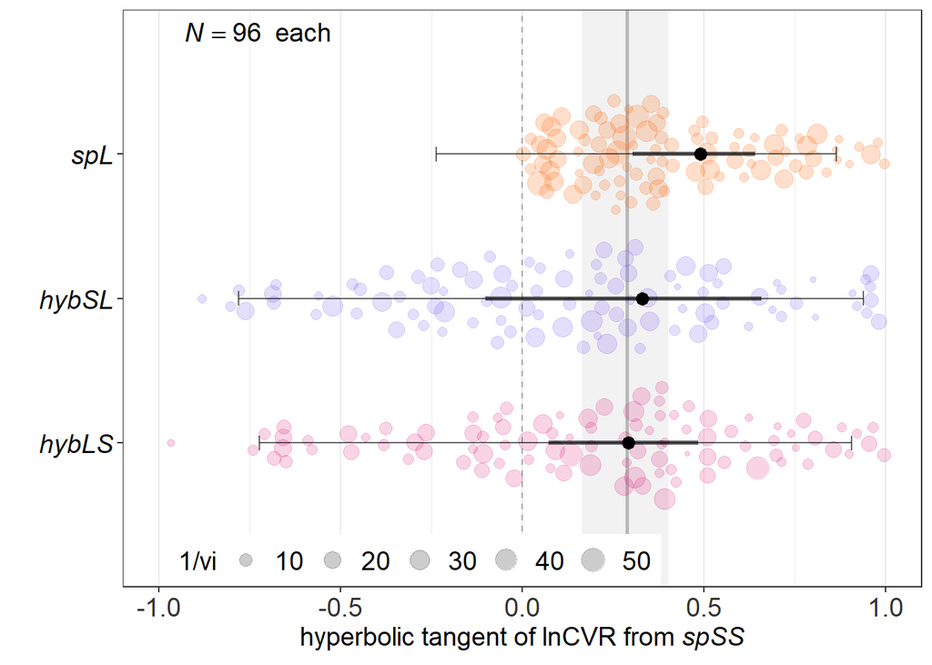

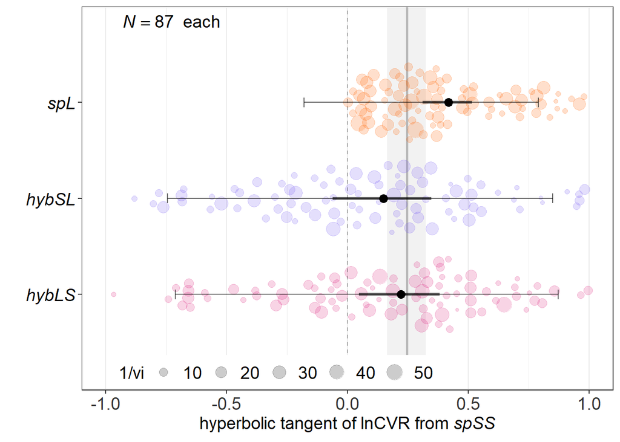

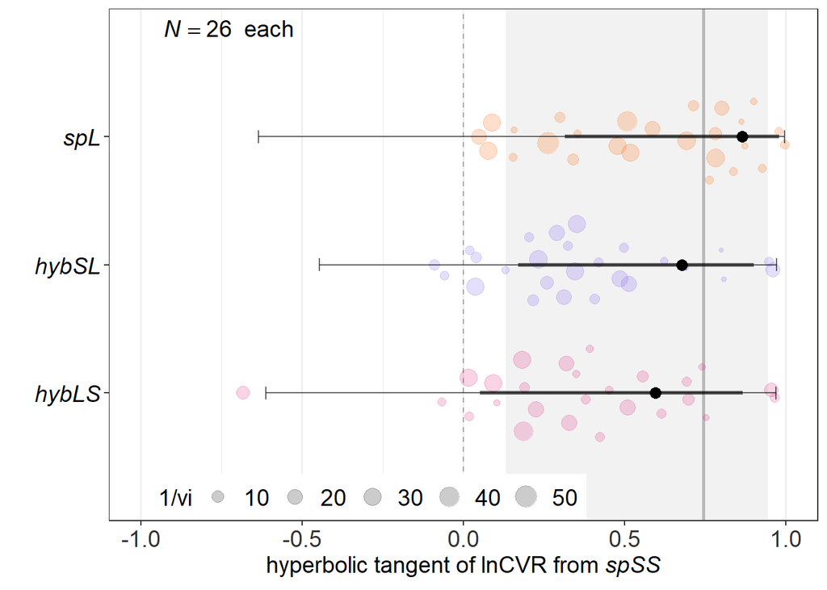

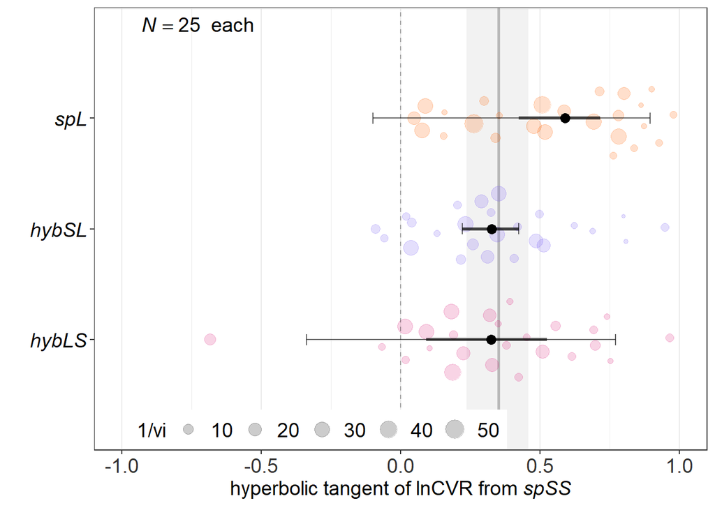

```r
> for (j in c("withTS", "withoutTS")) {
+   for (k in c("alltaxon", "insect")) {
+     for (h in c("spL", "hybLS", "hybSL")) {
+
+       if (k == "alltaxon") {
+         dat <- with.without.TS %>%
+           filter(cross == h, data.type == j)
+       } else {
+         dat <- with.without.TS %>%
+           filter(cross == h, data.type == j, insect == k)
+       }
+       # # Phylogenetic random meta-analysis
+       # phyl.random <- rma.mv(
+       #   yi = yi, V = vi,
+       #   data = dat, method = "REML",
+       #   random = list(~1 | spL.name, ~1 | Study.ID, ~1 | Cross.ID, ~1 | ES.ID),
+       #   R = list(spL.name = phylo_cor)
+       #   )
+       # saveRDS(phyl.random,
+       #   file = paste("../Analysis/Variation.meta", j, k, h, "obj", sep = "."))
+
+
+       ### Load model ###
+       phyl.random <- readRDS(paste("../Analysis/Variation.meta", j, k, h, "obj", sep = "."))
+       # Funnel plot
+       # funnel(phyl.random, xlab = paste(j, k, h))
+       # creating summary table of results
+       assign(
+         paste("res", h, sep = "."),
+         get_pred(phyl.random) %>%
+           as.data.frame() %>%
+           mutate(
+             N = length(dat$ES.ID),
+             # I2 = I2(phyl.random)["I2_total"] %>% round(3),
+             cross = h # indicate cross (spL, hybLS, hybSL)
+             )
+           )
+
+     }
+
+     if (k == "alltaxon") {
+       dat.plot <- with.without.TS %>%
+         filter(data.type == j)
+     } else {
+       dat.plot <- with.without.TS %>%
+         filter(data.type == j, insect == k)
+     }
+
+
+     # Bind result of all crosses at each dataset
+     assign(
+       paste("res.ma", j,k, sep = "."),
+       res.ma <- bind_rows(
+         res.spL, res.hybLS, res.hybSL
+         ) %>%
+         as.data.frame() %>%
+         within('Dataset' <- c(paste(j,k), "", "")) # Show dataset name in first row
+     )
+
+     ### Midparent estimate & CI ###
+     midparent.ma.2 <- midparent.ma %>%
+       filter(data.type == j, taxon == k)
+
+     # creating a forest plot
+     plot.metamean <- ggplot(
+       data = res.ma,
+       aes(x = tanh(Estimate), y = cross)
+       ) +
+       scale_y_discrete(expand = c(0,1)) +
+       scale_x_continuous(
+         limits = c(-1, 1),
+         breaks = seq(-1, 1, by = 0.5)
+         ) +
+       ### Midparent CI ###
+       geom_rect(
+         aes(
+           xmin = tanh(midparent.ma.2$LowerCI),
+           xmax = tanh(midparent.ma.2$UpperCI),
+           ymin = -Inf, ymax = Inf
+           ),
+         fill="Grey 95", inherit.aes = FALSE
+         ) +
+       ### Midparent estimate ###
+       geom_vline(
+         xintercept = tanh(midparent.ma.2$Estimate), colour = "grey20",
+         alpha = 0.3, size = 1
+         ) +
+       ### Orchard plot ###
+       geom_quasirandom(
+         data = dat.plot %>%
+           filter(data.type == j),
+         aes(x = tanh(yi), y = cross, size = 1/vi, color = cross),
+         alpha = 0.2, groupOnX = FALSE
+         ) +
+       scale_color_manual(values = c("#DC267F", "#785EF0", "#FE6100")) +
+       # Delete legend for colors
+       guides(fill = "none", colour = "none") +
+       ## Confidential interval ###
+       geom_errorbarh(
+         aes(xmin = tanh(LowerCI), xmax = tanh(UpperCI)),
+         height = 0, size = 1.2, alpha = 0.6
+         ) +
+       ### Prediction interval ###
+       geom_errorbarh(
+         aes(xmin = tanh(lowerPR), xmax = tanh(upperPR)),
+         height = 0.1, size = 0.5, alpha = 0.6
+         ) +
+       geom_vline(xintercept = 0, linetype = 2, colour = "black", alpha = 0.3) +
+       ### Estimate ###
+       geom_point(size = 3, shape = 21, fill = "black") +
+       ### N ###
+       annotate(
+         "text", x = -0.93, y = 3.85,
+         label = paste("italic(N)==", length(dat.plot$ES.ID)/3),
+         parse = TRUE, hjust = "left", size = 5
+       ) +
+       annotate(
+         "text", x = -0.68, y = 3.85,
+         label = "each", hjust = "left", size = 5
+       ) +
+       ylab("") +
+       xlab(expression(
+         paste("hyperbolic tangent of lnCVR from ", italic("spSS")),
+         parse = TRUE
+         )) +
+       theme_bw() +
+       theme(
+         panel.grid.major.y = element_blank(),
+         axis.text.y = element_text(size = 14, color = "black", face = "italic"),
+         axis.text.x = element_text(size = 14, color = "grey20"),
+         axis.title = element_text(size = 14, color = "black"),
+         legend.position = c(0.15, 0.002),
+         legend.justification = c(0.15, 0.002),
+         legend.text = element_text(size = 14),
+         legend.title = element_text(size = 14),
+         legend.direction = "horizontal"
+         )
+
+     print(plot.metamean)
+
+     ggsave(
+       plot = plot.metamean,
+       file = paste("../Analysis/variation.general.metamean", j, k, "svg", sep = "."),
+       height = 4, width = 5
+     )
+
+   }
+ }
```

```r
> bind_rows(
+   res.ma.withTS.alltaxon, res.ma.withoutTS.alltaxon,
+   res.ma.withTS.insect, res.ma.withoutTS.insect
+   ) %>%
+   as.data.frame() %>%
+   select(Dataset, cross, Estimate, UpperCI, LowerCI, contains("PR"), contains("I2")) %>%
+   kable("html", digits = 3) %>% kable_styling("striped", position = "left")
```

| Dataset | cross | Estimate | UpperCI | LowerCI | lowerPR | upperPR | I2[total] | %I2[species with phylogeny] | %I2[study] | %I2[crossed strain] | %I2[residual] |
| --- | --- | --- | --- | --- | --- | --- | --- | --- | --- | --- | --- |
| withTS alltaxon | spL | 0.538 | 0.763 | 0.314 | -0.240 | 1.317 | 68.9% | 12.7% | 12.1% | 0% | 44.1% |
|  | hybLS | 0.302 | 0.531 | 0.073 | -0.913 | 1.516 | 82.4% | 3.2% | 10.8% | 0% | 68.4% |
|  | hybSL | 0.345 | 0.790 | -0.101 | -1.048 | 1.738 | 84.8% | 24.5% | 18.4% | 0% | 41.8% |
| withoutTS alltaxon | spL | 1.313 | 2.297 | 0.328 | -0.751 | 3.377 | 92.6% | 75.2% | 0% | 5.7% | 11.7% |
|  | hybLS | 0.686 | 1.321 | 0.052 | -0.713 | 2.085 | 82.5% | 50.7% | 28% | 0% | 3.9% |
|  | hybSL | 0.826 | 1.480 | 0.172 | -0.481 | 2.132 | 79.7% | 79.7% | 0% | 0% | 0% |
| withTS insect | spL | 0.446 | 0.570 | 0.322 | -0.181 | 1.073 | 61.4% | 0% | 14.2% | 0% | 47.3% |
|  | hybLS | 0.226 | 0.403 | 0.048 | -0.892 | 1.343 | 80.5% | 0% | 8.9% | 0% | 71.6% |
|  | hybSL | 0.151 | 0.362 | -0.061 | -0.957 | 1.259 | 79.5% | 0% | 23.3% | 0% | 56.2% |
| withoutTS insect | spL | 0.677 | 0.901 | 0.454 | -0.098 | 1.453 | 68.4% | 0% | 0% | 22.4% | 46% |
|  | hybLS | 0.338 | 0.583 | 0.093 | -0.351 | 1.027 | 55.3% | 0% | 43.2% | 0% | 12.2% |
|  | hybSL | 0.340 | 0.454 | 0.226 | 0.226 | 0.454 | 0% | 0% | 0% | 0% | 0% |

# comparing mean across all crosses

Comparing the differences between parentals and hybrids

```r
> for (j in c("withTS", "withoutTS")) {
+   for (k in c("alltaxon", "insect")) {
+
+     if (k == "alltaxon") {
+       dat <- with.without.TS %>%
+         filter(data.type == j)
+     } else {
+       dat <- with.without.TS %>%
+         filter(data.type == j, insect == k)
+     }
+
+   ###############################################
+   # phylogenetic random regresson (ANOVA)
+   ###############################################
+   # # Regress by lnRR of phenotypic difference between parentals
+   # phyl.random.spL <- rma.mv(
+   #   yi = yi, V = vi,
+   #   data = dat, method = "REML",
+   #   random = list(~1 | spL.name, ~1 | Study.ID, ~1 | Cross.ID, ~1 | ES.ID),
+   #   R = list(spL.name = phylo_cor),
+   #   mods = ~ relevel(cross, ref = "spL")
+   #   )
+   # phyl.random.hybLS <- rma.mv(
+   #   yi = yi, V = vi,
+   #   data = dat, method = "REML",
+   #   random = list(~1 | spL.name, ~1 | Study.ID, ~1 | Cross.ID, ~1 | ES.ID),
+   #   R = list(spL.name = phylo_cor),
+   #   mods = ~ cross
+   #   )
+   # # Save model ###
+   # saveRDS(
+   #   phyl.random.spL,
+   #   file = paste("../Analysis/Variation.compare.from.spL", j, k, "obj", sep = ".")
+   #   )
+   # saveRDS(
+   #   phyl.random.hybLS,
+   #   file = paste("../Analysis/Variation.compare.from.hybLS", j, k, "obj", sep = ".")
+   #   )
+
+
+   ### Load model ###
+   # phyl.random.spL <- readRDS(paste("../Analysis/Variation.compare.from.spL", j, k, "obj", sep = "."))
+   phyl.random.hybLS <- readRDS(paste("../Analysis/Variation.compare.from.hybLS", j, k, "obj", sep = "."))
+
+   assign(
+     paste("Reciprocal", j,k, sep = "."),
+     get_reg(phyl.random.hybLS) %>%
+       # Show dataset name
+       within(Dataset <- c(paste(j,k), rep("", length(.$Estimate)-1))) %>%
+       # Rename fixed effects
+       within('Fixed effects' <- c("", "hybLS (intrcpt)", "hybSL", "spLL")) %>%
+       # Difference with midparent in %
+       mutate('Comparison with hybridLS' = c(
+         rep("", 2),
+         paste(
+           round(
+             (exp(phyl.random.hybLS$beta[1]+phyl.random.hybLS$beta[2]) -
+                exp(phyl.random.hybLS$beta[1])
+              )*100,
+             2),
+           "% larger"
+           ),
+         ""
+         )
+       )
+     )
+   }
+ }
>
> bind_rows(
+   Reciprocal.withTS.alltaxon, Reciprocal.withoutTS.alltaxon,
+   Reciprocal.withTS.insect, Reciprocal.withoutTS.insect
+   ) %>%
+   kable("html", digits = 3) %>% kable_styling("striped", position = "left")
```

Dataset

Fixed effects

Estimate

LowerCI

UpperCI

P

I2[total]

%I2[species with phylogeny]

%I2[study]

%I2[crossed strain]

%I2[residual]

significance

Comparison with hybridLS

withTS alltaxon

78.2%

20.1%

9.6%

0%

48.5%

hybLS (intrcpt)

0.377

0.055

0.700

0.022

hybSL

-0.074

-0.155

0.006

0.070

-10.44 % larger

spLL

0.190

0.112

0.268

0.000

withoutTS alltaxon

85.8%

65.8%

0%

4.3%

15.7%

hybLS (intrcpt)

0.785

0.082

1.488

0.029

hybSL

0.049

-0.109

0.206

0.544

10.94 % larger

spLL

0.323

0.170

0.476

0.000

withTS insect

72.1%

0.8%

14.2%

0%

57.1%

hybLS (intrcpt)

0.258

0.095

0.420

0.002

hybSL

-0.100

-0.183

-0.016

0.019

-12.26 % larger

spLL

0.178

0.098

0.258

0.000

withoutTS insect

59.7%

0%

0%

19.5%

40.2%

hybLS (intrcpt)

0.369

0.165

0.572

0.000

hybSL

0.046

-0.116

0.208

0.577

6.82 % larger

spLL

0.299

0.144

0.454

0.000

# PET-PEESE

Meta regression for spLL, hybSL, hybLS and midparent only including V (lnRR.sv or lnCVR.sv) as a moderator -> intercept indicates adjusted effect size (no error)

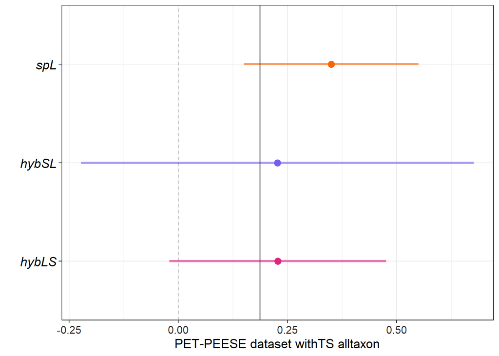

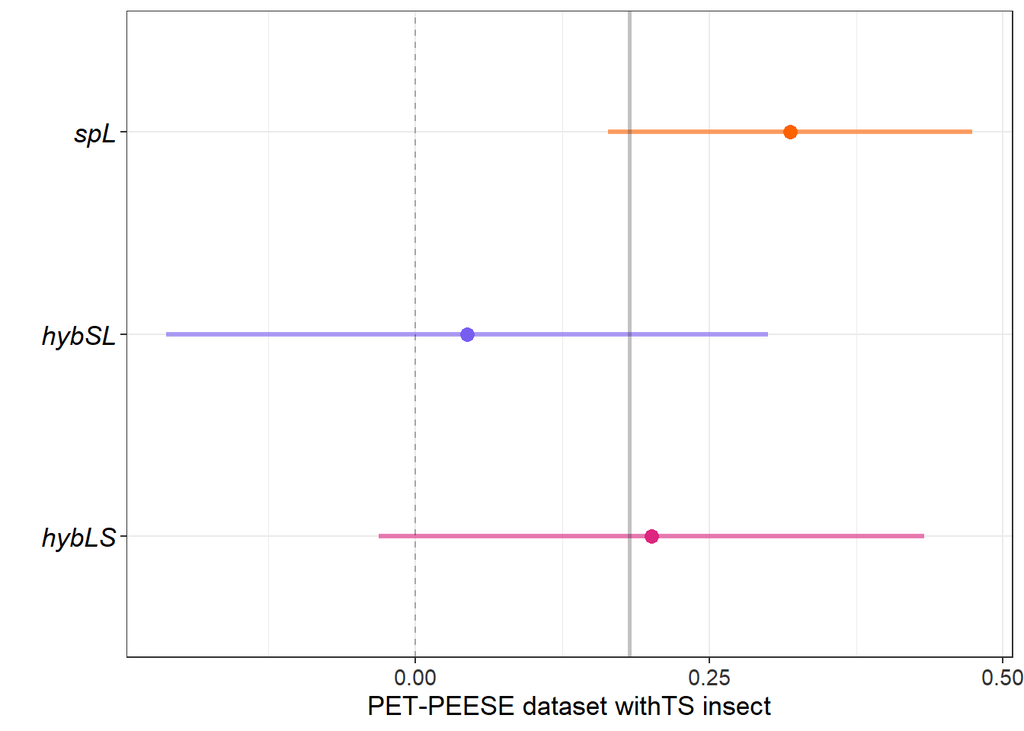

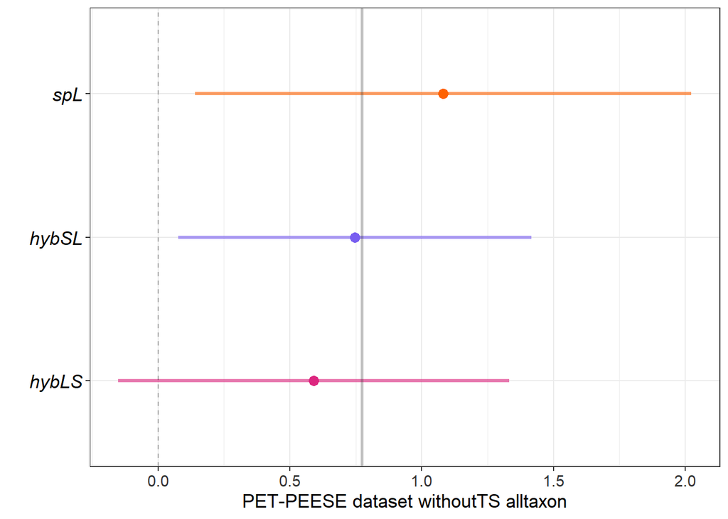

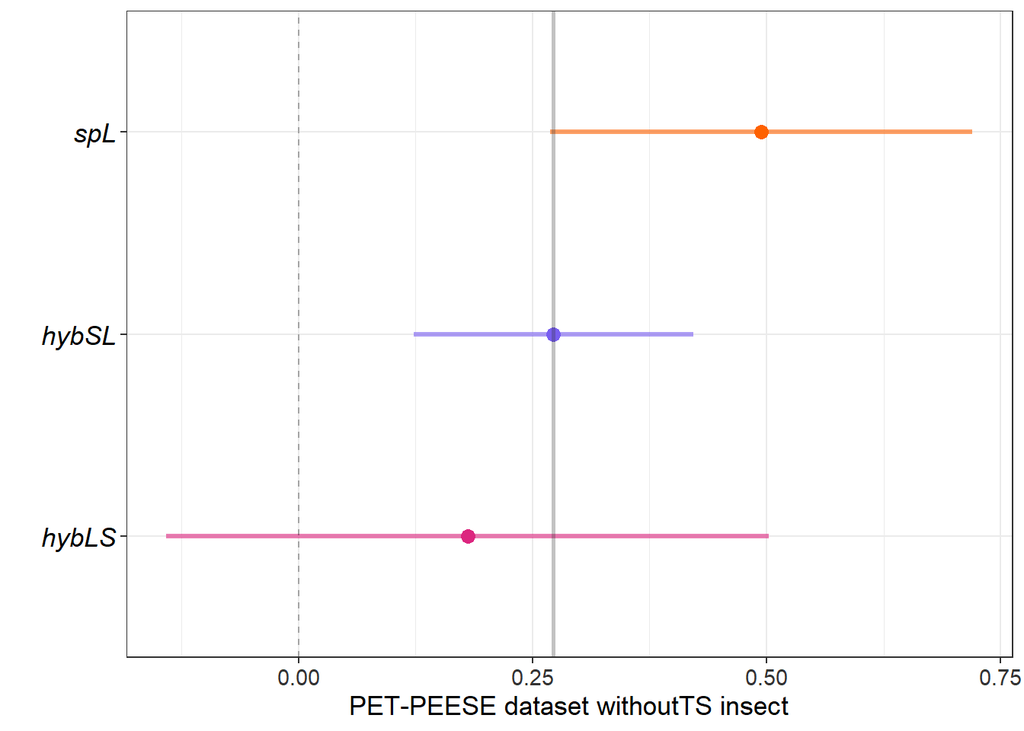

```r
> for (j in c("withTS", "withoutTS")) {
+   for (k in c("alltaxon", "insect")) {
+
+     if (k == "alltaxon") {
+       midparent.dat <- midparent %>%
+         filter(data.type == j)
+     } else {
+       midparent.dat <- midparent %>%
+         filter(data.type == j, insect == k)
+     }
+     # # Phylogenetic random meta-analysis for midparent
+     # midparent.random <- rma.mv(
+     #   yi = lnCVR.midparent.es, V = vi,
+     #   data = midparent.dat %>% filter(cross == "midparent"),
+     #   method = "REML",
+     #   mods = ~ vi,
+     #   random = list(~1 | spL.name, ~1 | Study.ID, ~1 | Cross.ID, ~1 | ES.ID),
+     #   R = list(spL.name = phylo_cor)
+     #   )
+     # ### Save model ###
+     # saveRDS(
+     #   midparent.random,
+     #   file = paste("../Analysis/variation.PET-PEESE.midparent", j, k, "obj", sep = ".")
+     #   )
+
+     ### Load model ###
+     midparent.random <- readRDS(paste("../Analysis/variation.PET-PEESE.midparent", j, k, "obj", sep = "."))
+     # creating summary table of results
+
+     midparent.ma <- get_reg(midparent.random) %>%
+       as.data.frame() %>%
+       mutate(
+         N = length(midparent.dat$ES.ID),
+         # I2 = I2(midparent.random)["I2_total"] %>% round(3),
+         cross = "midparent" # indicate cross (spL, hybLS, hybSL)
+         )
+
+     for (h in c("spL", "hybLS", "hybSL")) {
+
+       if (k == "alltaxon") {
+         dat <- with.without.TS %>%
+           filter(cross == h, data.type == j)
+       } else {
+         dat <- with.without.TS %>%
+           filter(cross == h, data.type == j, insect == k)
+       }
+       # # Phylogenetic random meta-analysis
+       # phyl.random <- rma.mv(
+       #   yi = yi, V = vi,
+       #   data = dat, method = "REML",
+       #   mods = ~ vi,
+       #   random = list(
+       #     ~1 | spL.name, ~1 | Study.ID, ~1 | Cross.ID, ~1 | ES.ID
+       #     ),
+       #   R = list(spL.name = phylo_cor)
+       #   )
+       # saveRDS(phyl.random,
+       #   file = paste("../Analysis/variation.PET-PEESE", j, k, h, "obj", sep = "."))
+
+
+       ### Load model ###
+       phyl.random <- readRDS(paste("../Analysis/variation.PET-PEESE", j, k, h, "obj", sep = "."))
+
+       assign(
+         paste("res", h, sep = "."),
+         get_reg(phyl.random) %>%
+           as.data.frame() %>%
+           mutate(
+             N = length(dat$ES.ID),
+             # I2 = I2(phyl.random)["I2_total"] %>% round(3),
+             cross = h # indicate cross (spL, hybLS, hybSL)
+             )
+           )
+
+     }
+
+     # Bind result of all crosses at each dataset
+     assign(
+       paste("res.ma", j,k, sep = "."),
+       res.ma <- bind_rows(
+         res.spL, res.hybLS, res.hybSL, midparent.ma
+         ) %>%
+         as.data.frame() %>%
+         within('Dataset' <- c(paste(j,k), rep("", length = 11))) # Show dataset name in first row
+     )
+
+     res.ma.plot <- res.ma %>%
+       filter(`Fixed effects` == "intrcpt") %>%
+       filter(cross != "midparent")
+
+     # creating a forest plot
+     plot.metavariation <- ggplot(
+       data = res.ma.plot,
+       aes(x = Estimate, y = cross)
+       ) +
+       # Delete legend for colors
+       guides(fill = "none", colour = "none") +
+       # Confidential interval : thicker line
+       geom_errorbarh(
+         aes(xmin = LowerCI, xmax = UpperCI, color = cross),
+         height = 0, size = 1.2, alpha = 0.6
+         ) +
+       geom_vline(xintercept = 0, linetype = 2, colour = "black", alpha = 0.3) +
+       ### Estimate ###
+       geom_point(size = 3, shape = 21, aes(fill = cross, color = cross)) +
+       scale_color_manual(values = c("#DC267F", "#785EF0", "#FE6100")) +
+       scale_fill_manual(values = c("#DC267F", "#785EF0", "#FE6100")) +
+       ylab("") +
+       xlab(paste("PET-PEESE dataset", j,k)) +
+       ### Midparent estimate ###
+       geom_vline(
+         xintercept = res.ma[11, "Estimate"], colour = "grey20",
+         alpha = 0.3, size = 1
+         ) +
+       theme_bw() +
+       theme(
+         axis.text.y = element_text(size = 13, color = "black", face = "italic"),
+         axis.text.x = element_text(size = 11, color = "grey20"),
+         axis.title = element_text(size = 13, color = "black"),
+         legend.position = c(0, 1),
+         legend.justification = c(0, 1),
+         legend.direction = "horizontal",
+         legend.background = element_blank()
+         )
+
+     print(plot.metavariation)
+   }
+ }
```

```r
> bind_rows(
+   res.ma.withTS.alltaxon, res.ma.withoutTS.alltaxon,
+   res.ma.withTS.insect, res.ma.withoutTS.insect
+   ) %>%
+   as.data.frame() %>%
+   mutate_at(vars('Estimate':'P'), as.numeric) %>%
+   select(Dataset, cross, 'Fixed effects', Estimate, UpperCI, LowerCI, contains("PR"), contains("V")) %>%
+   kable("html", digits = 3) %>% kable_styling("striped", position = "left")
```

| Dataset | cross | Fixed effects | Estimate | UpperCI | LowerCI |
| --- | --- | --- | --- | --- | --- |
| withTS alltaxon | spL |  |  |  |  |
|  | spL | intrcpt | 0.350 | 0.550 | 0.150 |
|  | spL | vi | 1.578 | 2.649 | 0.508 |
|  | hybLS |  |  |  |  |
|  | hybLS | intrcpt | 0.228 | 0.476 | -0.021 |
|  | hybLS | vi | 0.473 | 1.641 | -0.696 |
|  | hybSL |  |  |  |  |
|  | hybSL | intrcpt | 0.227 | 0.677 | -0.223 |
|  | hybSL | vi | 0.876 | 2.059 | -0.308 |
|  | midparent |  |  |  |  |
|  | midparent | intrcpt | 0.187 | 0.303 | 0.071 |
|  | midparent | vi | 1.104 | 1.979 | 0.228 |
| withoutTS alltaxon | spL |  |  |  |  |
|  | spL | intrcpt | 1.081 | 2.023 | 0.140 |
|  | spL | vi | 1.418 | 3.138 | -0.301 |
|  | hybLS |  |  |  |  |
|  | hybLS | intrcpt | 0.590 | 1.331 | -0.150 |
|  | hybLS | vi | 1.126 | 2.983 | -0.731 |
|  | hybSL |  |  |  |  |
|  | hybSL | intrcpt | 0.746 | 1.417 | 0.076 |
|  | hybSL | vi | 0.783 | 2.204 | -0.638 |
|  | midparent |  |  |  |  |
|  | midparent | intrcpt | 0.773 | 1.525 | 0.021 |
|  | midparent | vi | 1.126 | 2.552 | -0.299 |
| withTS insect | spL |  |  |  |  |
|  | spL | intrcpt | 0.319 | 0.474 | 0.164 |
|  | spL | vi | 1.389 | 2.446 | 0.331 |
|  | hybLS |  |  |  |  |
|  | hybLS | intrcpt | 0.201 | 0.433 | -0.031 |
|  | hybLS | vi | 0.205 | 1.378 | -0.969 |
|  | hybSL |  |  |  |  |
|  | hybSL | intrcpt | 0.044 | 0.300 | -0.212 |
|  | hybSL | vi | 0.848 | 2.009 | -0.313 |
|  | midparent |  |  |  |  |
|  | midparent | intrcpt | 0.182 | 0.293 | 0.071 |
|  | midparent | vi | 0.902 | 1.805 | -0.001 |
| withoutTS insect | spL |  |  |  |  |
|  | spL | intrcpt | 0.494 | 0.720 | 0.269 |
|  | spL | vi | 1.481 | 2.821 | 0.140 |
|  | hybLS |  |  |  |  |
|  | hybLS | intrcpt | 0.181 | 0.502 | -0.141 |
|  | hybLS | vi | 1.192 | 2.856 | -0.473 |
|  | hybSL |  |  |  |  |
|  | hybSL | intrcpt | 0.272 | 0.422 | 0.123 |
|  | hybSL | vi | 0.796 | 1.935 | -0.342 |
|  | midparent |  |  |  |  |
|  | midparent | intrcpt | 0.272 | 0.412 | 0.132 |
|  | midparent | vi | 1.146 | 2.286 | 0.007 |